# 2014-09-18-hw1-sz2491

Siqian Zhu

9/18/2014

# Hi, everyone!

The dataset I choose is “*GSS2006*” in **csv** form.

```r
setwd ("/Users/ac/Documents/columbia/study/2014fall/datavisualization")
d=read.csv("GSS2006.csv")
```

> The GSS contains a standard ‘core’ of demographic, behavioral, and attitudinal questions, plus topics of special interest. Many of the core questions have remained unchanged since 1972 to facilitate time-trend studies as well as replication of earlier findings. The GSS takes the pulse of America, and is a unique and valuable resource. It has tracked the opinions of Americans over the last four decades.

Quoted from http://www3.norc.org/Gss+website/)

In this homework, I want to exam the relationship between two variables, “coop” and “happy”. The former one indicates the respondent’s attitudes towards the interview while the latter one reports people’s happiness level in recent days. The description of these two varible can be seen as follows.

Table 1: coop, from the Electronic Codebook 254) In general, what was the respondent’s attitude toward the interview? (COOP) TOTAL % 1) Friendly and interested 3686 81.7 2) Cooperative but not particularly interested 665 14.7 3) Impatient and restless 143 3.2 4) Hostile 9 0.2 9) No answer 7 0.2 TOTAL 4510 100.0

Table 2: happy, from the Electronic Codebook 159) Taken all together, how would you say things are these days – would you say that you are very happy, pretty happy, or not too happy? (HAPPY) TOTAL % 1) Very happy 920 30.7 2) Pretty happy 1676 56.0 3) Not too happy 390 13.0 8) Don’t know 6 0.2 Missing 1518  
TOTAL 2992 100.0

First, let’s see them individually, using histogram. Colors are added into the bars.

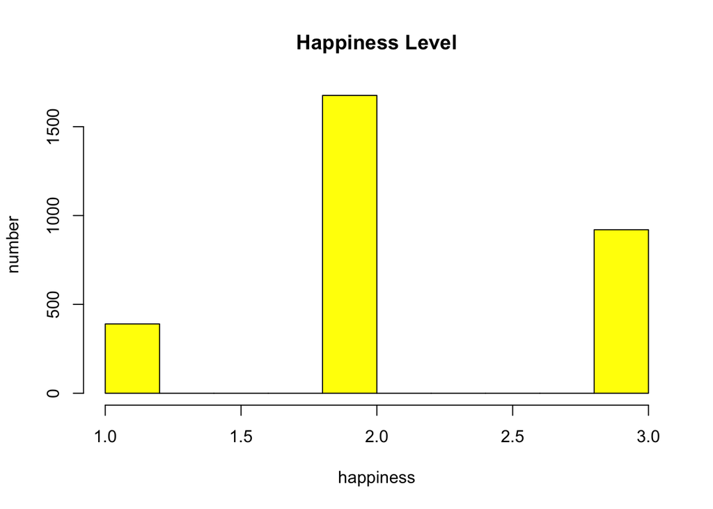

```r
d$happy1=4-d$happy
d$happy1.lab=ordered(d$happy1, levels=c(1,2,3), labels=c("very happy", "pretty happy", "not too happy"))
hist(d$happy1, main="Happiness Level", xlab="happiness", ylab="number", col="yellow")
```

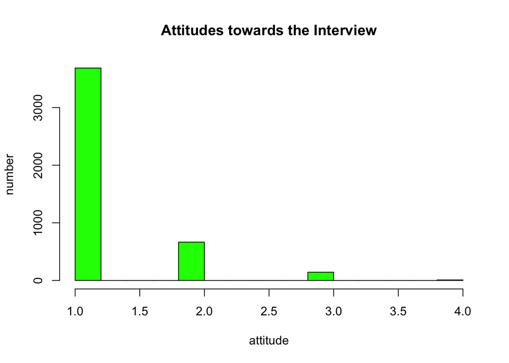

```r
hist(d$coop, main="Attitudes towards the Interview", xlab="attitude", ylab="number", col="green")
```

Then I will use ggplot2 to draw picture.

[figure not shown]

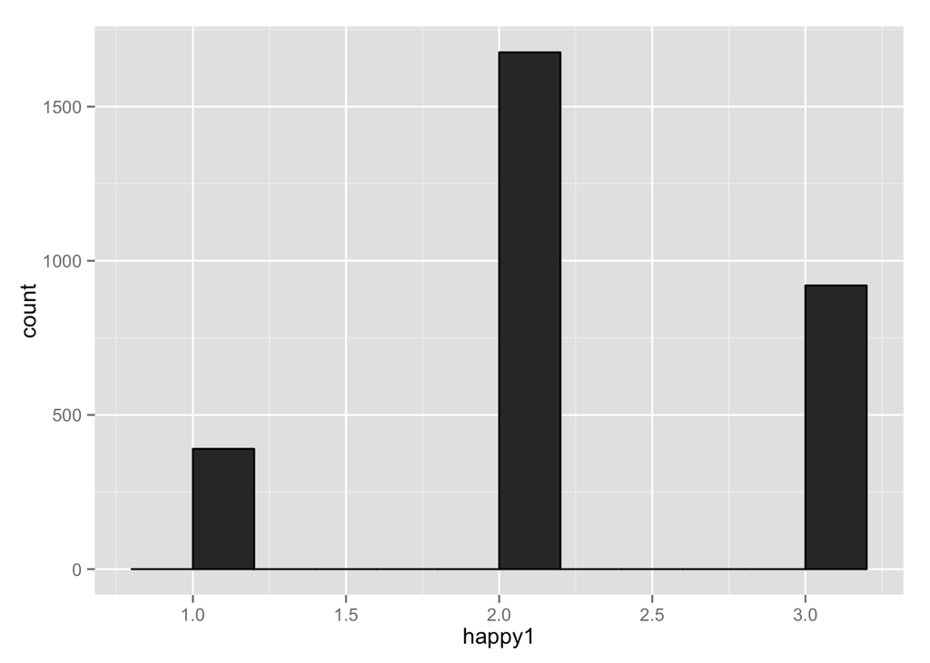

to be continued